# case_study1

Prudhvi

4/10/2022

## Load Libraries

Load the required libraries

```r
library(ggplot2)
library(dplyr)
library(stringr)
library(ggrepel)
library(GGally)
library(RColorBrewer)
library(maps)
library(alluvial)
library(randomForest)
```

## Removing Scientific Values

```r
options(scipen = 100)
```

## Load the Data

Load the data and check to see if everything is consistent using str(). - Check if there are NA values present - Replace Null Character with NA - Change the format of date from Character to Date

```r
loans <- read.csv('loans_full_schema.csv',header = T)
str(loans)
sum(is.na(loans))

# Empty Character to NA
loans[loans==''] <- NA

# Change Date format
loans$issue_month<-  paste(loans$issue_month, "-01",sep="")
loans$issue_month<- as.Date(loans$issue_month,"%b-%Y-%d")
```

## Visualizations

### Geographic Heatmap

In this geographic heat map, we can observe that there are more states with an average interest rate of between 12 and 13%.

Also, states like California, New York, Pennsylvania, New Hampshire, and Delaware had an average of 13-14% interest rate on loans. Most of which are on the eastern coast

Then, we have Iowa where there is no loan reportedly taken. Looks like Forbes Richest People are living in Iowa.

Lastly, we have states like Vermont, Arizona, New Mexico, Kansas, Missouri, Kentucky, North Dakota, Wyoming, and Oregon have an average interest rate between 11-12%.

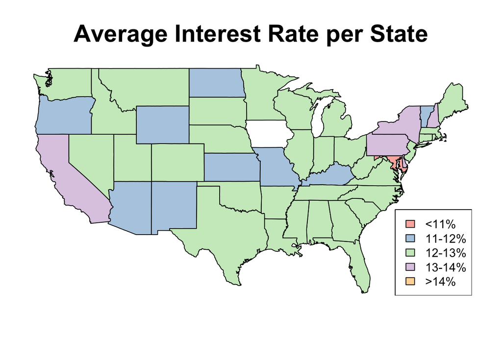

### Bar Chart

This is a simple bar chart that shows the purpose of loan for people in management positions. As we can see, most of them have taken a loan for debit consolidation which refers to taking a loan to pay off multiple debts, followed by credit card payment.

There is very nice manager who spent money on Renewable Energy. Kudos!

From the initial data set we have almost 1400+ managers and very few of them received a loan on House, Medical reasons, Car, Vacation.

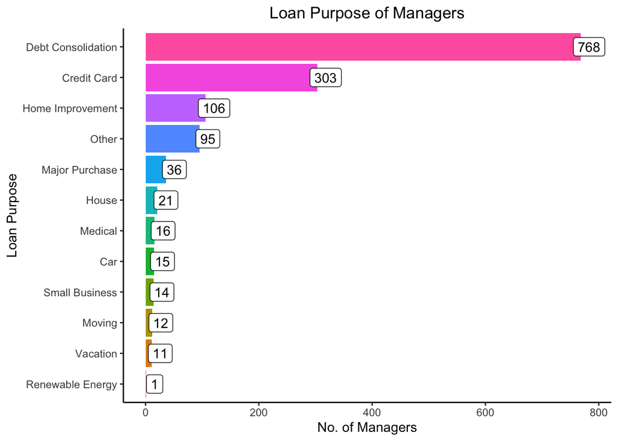

### Parallel Coordination

First let us see the term, very few people have got the 60 months loan term. Also,people who had own home, took a lower loan term.

Next, interest rate which shows which is dependent on he annual income i.e. people with higher annual income have got higher interest rates and people with lower annual income have got lower interest rates. Now this variability is because of the loan amount taken. People who took low loan amounts have got higher interest rates.

The loan grade show another story, there are very few hiring managers with a E grade or D grade loan. While, there are more individuals with a C grade loan than a A or B grade loan.

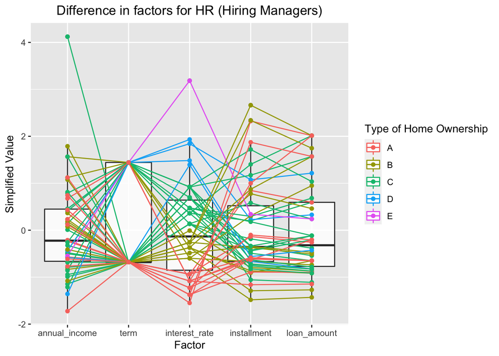

### Alluvial Plot

This is an alluvial plot which shows how many people have paid off their loan depending on grade, month issued, and, application type. Looks like people who took a C grade are more likely to pay it off followed by B grade, A and C grade.

Note: All of the loans people took here were below $700.

On the other hand, if the loan was issued in January, it is more likely that it will get paid off. It is followed by February and March.

The last criteria is loan application type and if you are an individual and took a C grade loan in January, there are higher chances for you to pay the loan on time. Contrast to this, of you have a G grade loan issued in March and you hace a joint account you are less likely to pay it on time.

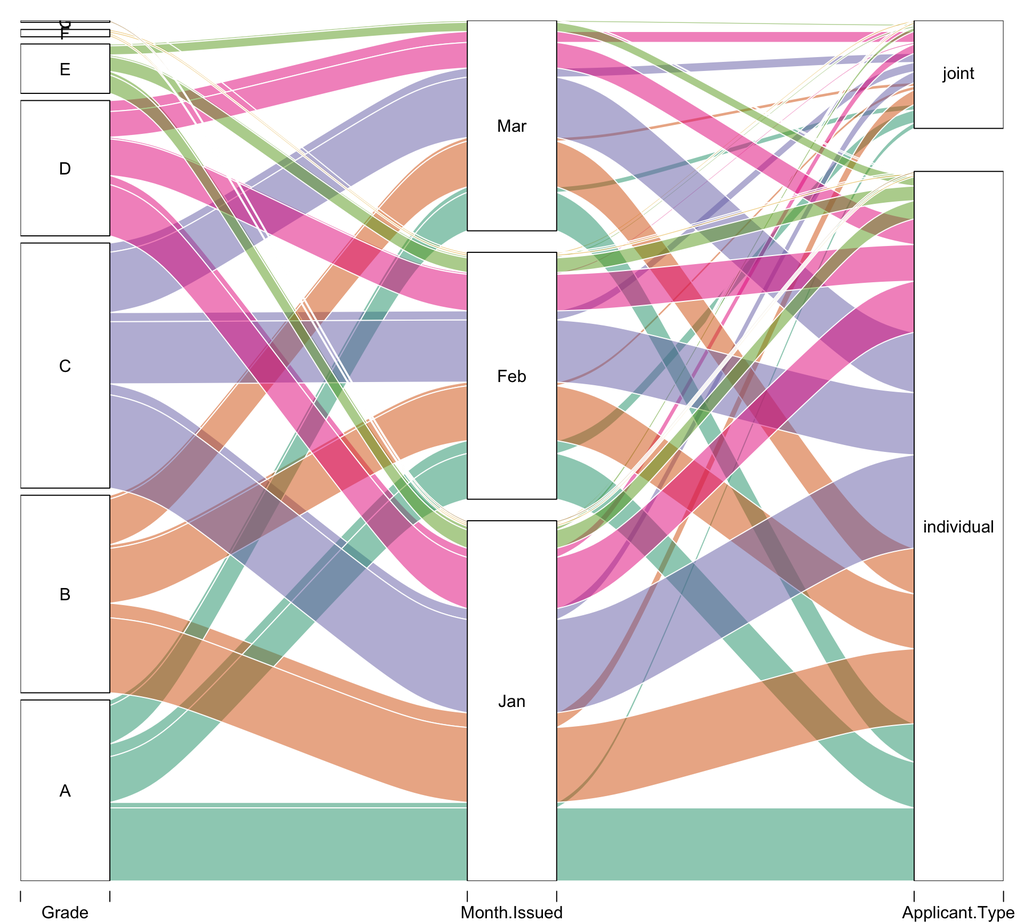

### Facet Scatter Plot

This scatter plot shows the difference between annual income and loan amount in each plot and overall is divided by the number of historical failed to pay as an integer and public bankruptcy record as interger.

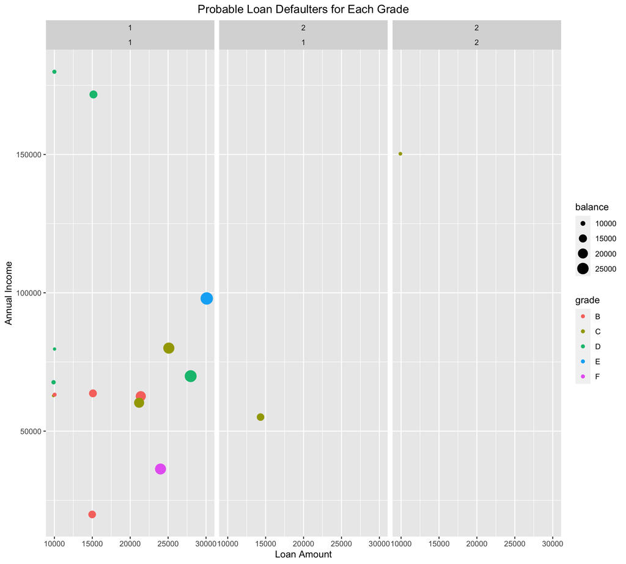

### Histogram

This was a simple visualization. We can infer only one thing from this type of plot but sometimes they are really important. In this data, we can see that residents of California have taken more loans below $20,000. It may have been because of the higher interest rate we have seen in the first graph.

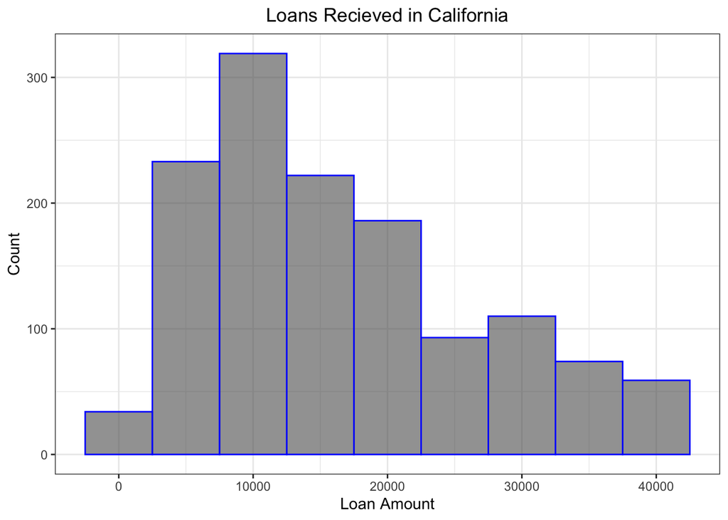

## Linear Regression

For this prediction analysis I used the Generalized Linear Regression Method to predict interest rate given grade. This prediction model had an accuracy of 97.69 %. We can see how powerful the grade variable is in this linear regression algorithm.

The plot below is a jitters plot and we can see how well the algorithm performed. The testing data had 2000 rows and we can see how clean the graph is. The algorithm can be even more better if we can be able to find the other influencing factor.

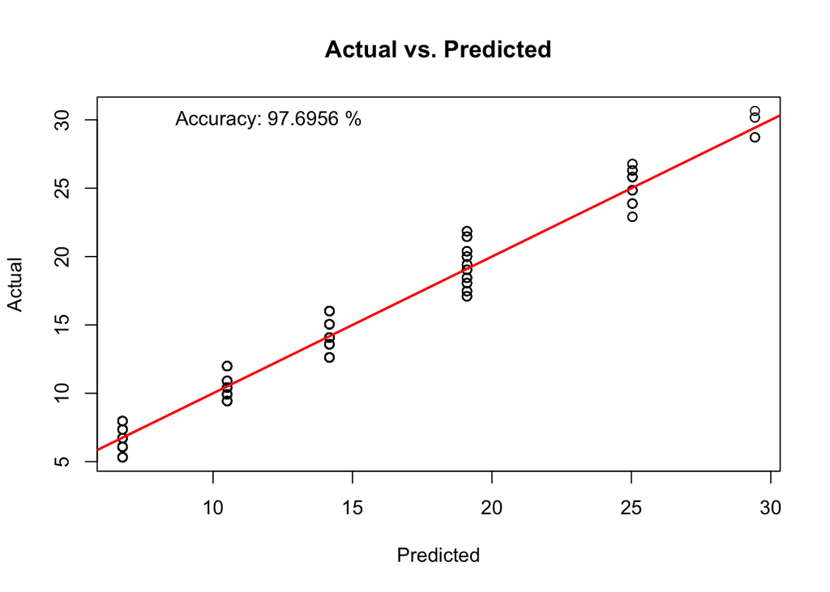

## Random Forests

For this random forests algorithm, i used the default 500 forests to find the interest rate given verified income, loan amount, installment, total_credit-utilized, term and application type.

Even after specifying a lot of variables to make a better prediction the model had an accuracy of about 82.06%. Grade as we have seen in the linear regression has a strong influence on interest rate.

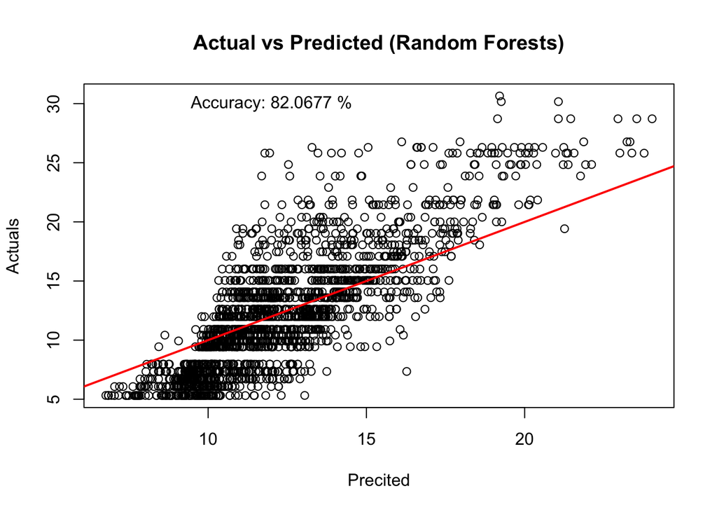

If I had more time, I would create a training data set with variables in different order and also set a bias variable to add any bias in the process to attain model accuracy. Also, for different algorithms we can be able to select the learning rate and variables as such which can help produce more effective and better predictions. They do require a lot of time to create and find the exact variables.